# PSY 8712 Week 8 Project

Amanda Jensen

### Reproducible Image and Online Resources

An image of this project as of *March 18 2024* can be accessed by [clicking this link](https://hub.ovh2.mybinder.org/user/jens2482-psy8712-week8-71cbvnyk/lab). An interactive web app is available by [clicking this link](http://jens2482.shinyapps.io/shiny_week8) instead.

### Script Settings and Resources

```r
#setwd(dirname(rstudioapi::getActiveDocumentContext()$path))
library(tidyverse)
```

### Data Import and Cleaning

In this chunk, I cleaned the data using the same techniques we used in Week 7, I made sure all the variables had an appropriate class designation and changed reverse coded q5 by subtracting all values from 6.

```r
week8_tbl <- read_csv ("../data/week3.csv") %>%
  mutate(timeStart = ymd_hms (timeStart)) %>%
  mutate(condition = factor(condition,
                            levels = c("A", "B", "C"),
                            labels = c("Block A", "Block B", "Control"))) %>%
  mutate(gender = factor(gender,
                         levels = c("M", "F"),
                         labels = c("Male", "Female"))) %>%
  mutate(q5 = 6 - q5)
```

### Visualization

This chunk creates a paginated table for questions 1-6, and I did this using brackets to select just those columns. For the scatterplot I compared the mean of the row for questions 1-6 to the mean of the row for questions 8-10.

| q1 | q2 | q3 | q4 | q5 | q6 |
| --- | --- | --- | --- | --- | --- |
| 5 | 4 | 4 | 1 | 2 | 1 |
| 2 | 4 | 3 | 1 | 3 | 1 |
| 5 | 5 | 2 | 1 | 5 | 1 |
| 4 | 3 | 4 | 2 | 4 | 1 |
| 3 | 1 | 3 | 5 | 2 | 1 |
| 4 | 3 | 2 | 3 | 3 | 1 |
| 2 | 4 | 1 | 3 | 1 | 1 |
| 4 | 2 | 5 | 1 | 1 | 1 |
| 2 | 5 | 3 | 4 | 2 | 1 |
| 3 | 4 | 2 | 4 | 5 | 1 |

[output cut: 39 more lines]

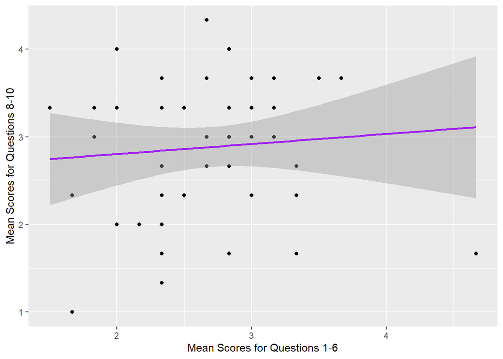

### Analysis

This chunk calculates the correlation and the corresponding p-value between means for questions 1-6 and questions 8-10.

```
##
##  Pearson's product-moment correlation
##
## data:  rowMeans(week8_tbl[, c(paste0("q", 1:6))]) and rowMeans(week8_tbl[, c(paste0("q", 8:10))])
## t = 0.58309, df = 47, p-value = 0.5626
## alternative hypothesis: true correlation is not equal to 0
## 95 percent confidence interval:
##  -0.2012466  0.3574248
## sample estimates:
##        cor
## 0.08474575
```

I observed a correlation of .08. However, since the p-value associated with this correlation is not less than .05, it is not statistically significant.

### Data Export

This chunk exports the dataset as a CSV file.